# Portfolio Replica - Regression

### General steps

First of all we download the necessary libraries:

```r
library(readxl)
library(GGally)
library(MASS)
library(car)
library(rgl)
library(glmnet)
library(dplyr)
library(quantmod)
library(writexl)
rm(list = ls())
graphics.off()
```

Then we upload our data set, be careful to change the path:

```r
setwd("D:/Download D/final proj")
```

```
Avvertimento: The working directory was changed to D:/Download D/final proj inside a notebook chunk. The working directory will be reset when the chunk is finished running. Use the knitr root.dir option in the setup chunk to change the working directory for notebook chunks.
```

```r
Data <- read_excel('InvestmentReplica.xlsx', sheet = "Replica")

head(Data)
```

| Date | MXWO | MXWD | LEGATRUU | HFRXGL | RX1 | TY1 | GC1 | CO1 | ES1 | VG1 | NQ1 | LLL1 | TP1 | DU1 | TU2 |
| --- | --- | --- | --- | --- | --- | --- | --- | --- | --- | --- | --- | --- | --- | --- | --- |
| 2007-10-23 | 1633.44 | 414.14 | 350.2138 | 1343.63 | 113.70 | 110.5156 | 759.0 | 82.85 | 1525.50 | 4393 | 2212.00 | 1287.0 | 1570.5 | 103.385 | 103.7188 |
| 2007-10-30 | 1663.89 | 423.26 | 352.5413 | 1356.53 | 113.79 | 110.6562 | 787.8 | 87.44 | 1536.00 | 4476 | 2217.75 | 1323.9 | 1610.5 | 103.410 | 103.8125 |
| 2007-11-06 | 1651.59 | 419.51 | 354.1758 | 1360.20 | 113.79 | 110.8750 | 823.4 | 93.26 | 1525.00 | 4425 | 2233.50 | 1320.0 | 1575.5 | 103.410 | 104.0469 |
| 2007-11-13 | 1601.81 | 405.98 | 357.2217 | 1347.16 | 114.35 | 111.7188 | 799.0 | 88.83 | 1483.25 | 4323 | 2066.75 | 1271.0 | 1440.5 | 103.595 | 104.3047 |
| 2007-11-20 | 1570.74 | 398.54 | 359.4446 | 1335.21 | 114.72 | 113.1562 | 791.4 | 95.49 | 1446.00 | 4296 | 2035.50 | 1225.2 | 1472.5 | 103.800 | 104.9453 |
| 2007-11-27 | 1561.93 | 395.11 | 361.7651 | 1325.03 | 115.08 | 113.9531 | 814.0 | 92.52 | 1426.50 | 4241 | 2032.50 | 1196.2 | 1485.0 | 103.925 | 105.1016 |

Then we create our two subsets, one with the assets and one with the targets:

```r
#define the functions to convert our data into log returns
price2ret<- function(prices){
  return(diff(log(prices)))
}
#and the other way around
ret2price <- function(returns, start_price = 1) {
  returns <- c(0, returns)  # Add a zero for the initial price
  prices <- start_price * exp(cumsum(returns))
  return(prices)
}

#Assets data set
Assets <- subset(Data, select = -c(Date, LLL1, MXWO, MXWD, LEGATRUU, HFRXGL))
Assets <- data.frame(
  CO1 = price2ret(Assets$CO1),
  DU1 = price2ret(Assets$DU1),
  ES1 = price2ret(Assets$ES1),
  GC1 = price2ret(Assets$GC1),
  NQ1 = price2ret(Assets$NQ1),
  RX1 = price2ret(Assets$RX1),
  TP1 = price2ret(Assets$TP1),
  TU2 = price2ret(Assets$TU2),
  TY1 = price2ret(Assets$TY1),
  VG1 = price2ret(Assets$VG1)
)

#Targets data set
Targets <- subset(Data, select = c(MXWO, MXWD, LEGATRUU, HFRXGL))
Targets <- data.frame(
  MXWO = price2ret(Targets$MXWO),
  MXWD = price2ret(Targets$MXWD),
  LEGATRUU = price2ret(Targets$LEGATRUU),
  HFRXGL = price2ret(Targets$HFRXGL)
)

#show the first row of the data sets
head(Assets)
```

|  | CO1 | DU1 | ES1 | GC1 | NQ1 | RX1 | TP1 | TU2 | TY1 | VG1 |
| --- | --- | --- | --- | --- | --- | --- | --- | --- | --- | --- |
| 1 | 0.05392110 | 0.0002417853 | 0.006859410 | 0.037242473 | 0.002596085 | 0.0007912436 | 0.025150650 | 0.0009034785 | 0.001271636 | 0.018717425 |
| 2 | 0.06443845 | 0.0000000000 | -0.007187225 | 0.044197859 | 0.007076693 | 0.0000000000 | -0.021972008 | 0.0022551314 | 0.001974891 | -0.011459512 |
| 3 | -0.04866686 | 0.0017873969 | -0.027758784 | -0.030081164 | -0.077592537 | 0.0049092761 | -0.089582407 | 0.0024747847 | 0.007581112 | -0.023320673 |
| 4 | 0.07229710 | 0.0019769046 | -0.025434502 | -0.009557417 | -0.015235836 | 0.0032304564 | 0.021971361 | 0.0061230777 | 0.012785055 | -0.006265248 |
| 5 | -0.03159669 | 0.0012035144 | -0.013577232 | 0.028156837 | -0.001474927 | 0.0031331618 | 0.008453136 | 0.0014877634 | 0.007017573 | -0.012885267 |
| 6 | -0.03285107 | -0.0018781157 | 0.025436098 | -0.015724957 | 0.014531057 | 0.0008685834 | 0.018018506 | 0.0020049760 | 0.006151342 | 0.025606613 |

```r
head(Targets)
```

|  | MXWO | MXWD | LEGATRUU | HFRXGL |
| --- | --- | --- | --- | --- |
| 1 | 0.018470014 | 0.021782567 | 0.006623953 | 0.009555062 |
| 2 | -0.007419774 | -0.008899284 | 0.004625622 | 0.002701779 |
| 3 | -0.030604220 | -0.032783466 | 0.008563197 | -0.009633075 |
| 4 | -0.019587394 | -0.018496028 | 0.006203465 | -0.008910090 |
| 5 | -0.005624610 | -0.008643662 | 0.006435044 | -0.007653482 |
| 6 | 0.019747013 | 0.022894028 | -0.001451441 | 0.004908577 |

```r
NA
```

Our goal is to replicate a black box index using a series of more liquid futures. We have chosen as target client a university student (age 20 – 25) and we build a monster index focused on stock market (assuming a risk-loving client persona due to the young age and the family situation).

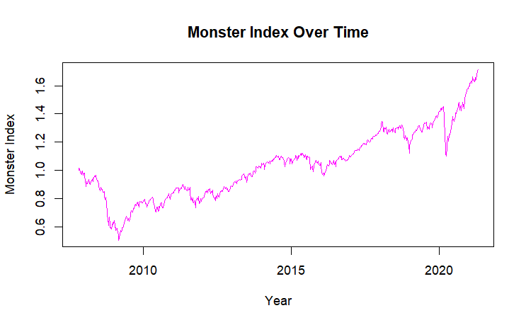

```r
MonsterIndex <- Targets$MXWO * 0.8 + Targets$LEGATRUU * 0.15 + Targets$HFRXGL * 0.05
MonsterIndex<-as.numeric(MonsterIndex)

plot(Data$Date, ret2price(MonsterIndex), type = "l",xlab = "Year", ylab = "Monster Index", col = "magenta", main = "Monster Index Over Time")
```

## Correlation Matrix

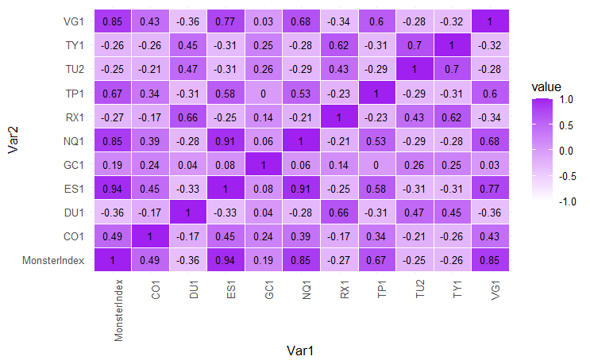

```r
correlation_set<-cbind(MonsterIndex, Assets)
correlation_matrix_A <- cor(correlation_set, use = "pairwise.complete.obs")

ggplot(data= reshape2::melt(correlation_matrix_A), aes(x = Var1, y = Var2, fill = value)) + geom_tile(color = "white") + geom_text(aes(label = round(value, 2)), color = "black", size = 3) + scale_fill_gradient2(low = "white", high = "dodgerblue", mid = 'purple', midpoint = 1, limit = c(-1,1)) +theme_minimal() + theme(axis.text.x = element_text(angle = 90, hjust = 1), axis.text.y = element_text(angle = 0))
```

From this correlation matrix we can see that ES1 and NQ1 are highly correlated (>0.9) therefore, we can say that they contribute to the variance of our data set the same way, but we wait to remove one of them as we want to explore their influence on the data more.

ES1 is a future on S&P 500 and NQ1 on Nasdaq100 i.e. the index of the first 500 US companies and the first 100 US tech companies so it’s obvious that they have high correlations (most likely the Nasdaq100 companies are also in S&P500)

## LINEAR REGRESSION

Let’s consider only a part of the data set to perform a first overview of our linear regression:

```r
AssetsTrain <- Assets[1:350,]
MonsterIndexTrain <- MonsterIndex[1:350]

attach(AssetsTrain)
```

```
I seguenti oggetti sono mascherati da AssetsTrain (pos = 4):

    CO1, DU1, ES1, GC1, NQ1, RX1, TP1, TU2, TY1, VG1
```

```r
Index.lm<- lm(MonsterIndexTrain ~ RX1 + TY1 + GC1 + CO1 + VG1 +
                 ES1 + TP1 + DU1 + NQ1 + TU2, data=AssetsTrain)

detach(AssetsTrain)
summary(Index.lm)
```

```
Call:
lm(formula = MonsterIndexTrain ~ RX1 + TY1 + GC1 + CO1 + VG1 +
    ES1 + TP1 + DU1 + NQ1 + TU2, data = AssetsTrain)

Residuals:
       Min         1Q     Median         3Q        Max
-0.0207375 -0.0031247  0.0002507  0.0031174  0.0167513

Coefficients:
              Estimate Std. Error t value Pr(>|t|)
(Intercept)  3.702e-05  2.584e-04   0.143  0.88619
RX1          3.093e-02  4.788e-02   0.646  0.51871
TY1          1.284e-01  4.396e-02   2.921  0.00373 **
GC1          6.780e-02  1.032e-02   6.571 1.88e-10 ***
CO1          3.507e-02  7.523e-03   4.662 4.51e-06 ***
VG1          2.239e-01  1.425e-02  15.708  < 2e-16 ***
ES1          4.581e-01  3.050e-02  15.020  < 2e-16 ***
TP1          1.030e-01  9.059e-03  11.366  < 2e-16 ***
DU1         -5.881e-01  1.929e-01  -3.048  0.00248 **
NQ1          1.745e-02  2.385e-02   0.732  0.46478
TU2          3.550e-01  1.845e-01   1.924  0.05525 .
---
Signif. codes:  0 ‘***’ 0.001 ‘**’ 0.01 ‘*’ 0.05 ‘.’ 0.1 ‘ ’ 1

Residual standard error: 0.004764 on 339 degrees of freedom
Multiple R-squared:  0.9584,    Adjusted R-squared:  0.9571
F-statistic: 780.3 on 10 and 339 DF,  p-value: < 2.2e-16
```

From the “Residuals” of the summary we can deduct that our residuals are distributed uniformly and symmetrically around zero, hence we can think that our distribution is normal, but we will perform other tests to confirm this assumption.

From the “Coefficients” we could see that the t-test is testing how relevant our coefficients are. For smalller values of the p-value we get more significant assets.

In the end looking at the ” R-squared” and “Adjusted R-squared” we get a high value, hence our model might overfit, since with a value equal to 1 we are in fact interpolating our data.

Now we print the VIF:

```r
vif(Index.lm)
```

```
      RX1       TY1       GC1       CO1       VG1       ES1       TP1       DU1       NQ1       TU2
 3.011878  2.637438  1.335138  1.742975  3.443858 10.081478  1.587978  2.448897  7.363216  2.153638
```

```r
# Rule of thumb -> problem when VIF exceeds 10 (or 5 sometimes)
# VIF > 5/10
```

As we expected from the correlation matrix we have a high value of VIF both for NQ1 and ES1, which are correlated as we saw before. This creates in our linear model a problem of collinearity, which can be solved through more complex regression models such as PCA regression, Lasso or Elastic Net.

We want to perform the residuals analysis to see if the assumptions for performing linear models are valid:

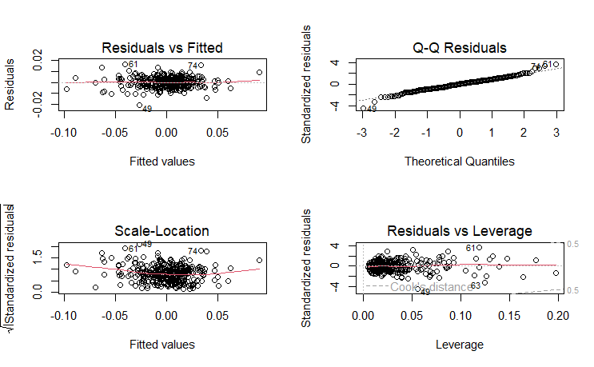

```r
par(mfrow=c(2,2))
plot(Index.lm)
```

Let’s discuss the different graphs:

1. The distribution of the Residuals doesn’t follow a particular distribution, thus we can assume homoscedasticity;
2. The QQ plot shows that there are only a few outliers that don’t follow perfectly the normal distribution, but since the majority of our points lays on the theoretical quantile we can assume normality;
3. The interpretation of this plot is more or less the same as the first one, since we don’t have any particular distribution we can assume homoscedasticity;
4. The dashed line indicates the Cook’s distance, since all our residuals fall inside this region we can say that there are no leverage point.

Through this analysis we can say that the assumptions of our linear regression are verified.

Prediction of the Train set:

```r
X<-predict(Index.lm, AssetsTrain)

plot(Data$Date[1:351], ret2price(X), type = "l", col = "purple", ylim = c(0.4, 1.2), ylab = "Price", xlab = "Year")
lines(Data$Date[1:351],ret2price(MonsterIndexTrain), type = "l", col = "magenta")
```

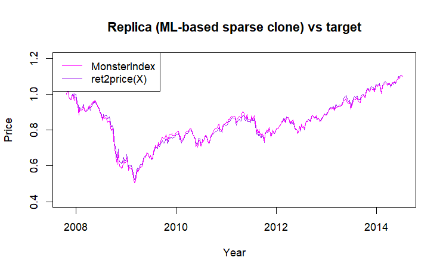

```r
legend("topleft", legend = c("MonsterIndex", "ret2price(X)"), col = c("magenta", "purple"), lty = 1)
title("Replica (ML-based sparse clone) vs target")
```

#### Back testing the model

Now we perform the rolling window and print our output.

```r
# 1. simple linear model
rollingWindow = 156 # in weeks (52 = 1Y, 104 = 2Y...)
n = dim(Assets)[1]
i = 1
b <- numeric(0)
r <- 0
endSample <- 0
res <- c()
bres <- c()
AssetsMatrix <- model.matrix(MonsterIndex ~ RX1 + TY1 + GC1 + CO1 + ES1 + VG1 + NQ1 + TP1 + DU1 + TU2, data=Assets) [,-1]

while (endSample < n-1) {
  startSample <- i
  endSample <- i + rollingWindow - 1
  X <- Assets[startSample:endSample,]
  y <- MonsterIndex[startSample:endSample]

  Index.lm <- lm(y ~ RX1 + TY1 + GC1 + CO1 + ES1 + VG1 +
                 NQ1 + TP1 + DU1 + TU2, data=X)

  b <- Index.lm$coefficients

  bres <- rbind(bres,b)
  B0 <- b[1]

  r <- B0 + AssetsMatrix[endSample+1,] %*% b[2:11]
  res <- c(res,r)

  i = i+1;
}

sum.lm <- summary(Index.lm)

start_index <- rollingWindow + 1
MonsterIndex_prices <- ret2price(MonsterIndex[start_index:n])
predicted_prices <- ret2price(res)

plot(Data$Date[1:549], MonsterIndex_prices, type = "l", col = "magenta", ylim = c(0.9, 2.2), ylab = "Price", xlab = "Year")
lines(Data$Date[1:549],predicted_prices, type = "l", col = "purple")
```

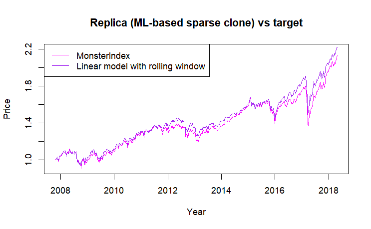

```r
legend("topleft", legend = c("MonsterIndex", "Linear model with rolling window"), col = c("magenta", "purple"), lty = 1)
title("Replica (ML-based sparse clone) vs target")
```

#### Computing indices

```r
# Computing MSE
MSE <- mean((MonsterIndex_prices - predicted_prices)^2)
MSE
```

```
[1] 0.002926986
```

```r
# (annualized) standard deviation of Tracking Error
TE = predicted_prices - MonsterIndex_prices
TEV <- sd(TE)*sqrt(52) # 52 means a year
TEV
```

```
[1] 0.2582789
```

```r
# annualized mean Excess Return
logRClone <- diff(log(predicted_prices))
logRTarget = diff(log(MonsterIndex_prices));
logTE =  logRClone - logRTarget;
meanTRTarget = exp(mean(logRTarget)*52) - 1
meanTRClone = exp(mean(logRClone)*52) - 1
meanER = exp(mean(logTE)*52) - 1

IR = meanER/TEV
IR
```

```
[1] 0.01456416
```

```r
# TurnOver
bres <- bres[,2:11]
Turnover = rowSums(abs(diff(bres)))/2 # weekly turnover
meanTurnover = mean(Turnover)*52 # average annual turnover
meanTurnover
```

```
[1] 2.582266
```

```r
tradingCosts = 0.001; #transaction costs (hp: buyCosts=sellCost)
meanTradingCosts = meanTurnover*tradingCosts
meanTradingCosts
```

```
[1] 0.002582266
```

```r
Linear.Index <- cbind(MSE, TEV, meanTRTarget,meanTRClone,meanER, IR, meanTurnover, meanTradingCosts)
Linear.Index
```

```
             MSE       TEV meanTRTarget meanTRClone      meanER         IR meanTurnover meanTradingCosts
[1,] 0.002926986 0.2582789   0.07422711  0.07826794 0.003761616 0.01456416     2.582266      0.002582266
```

## PCA REGRESSION

First of all let’s look at the distribution through box plots:

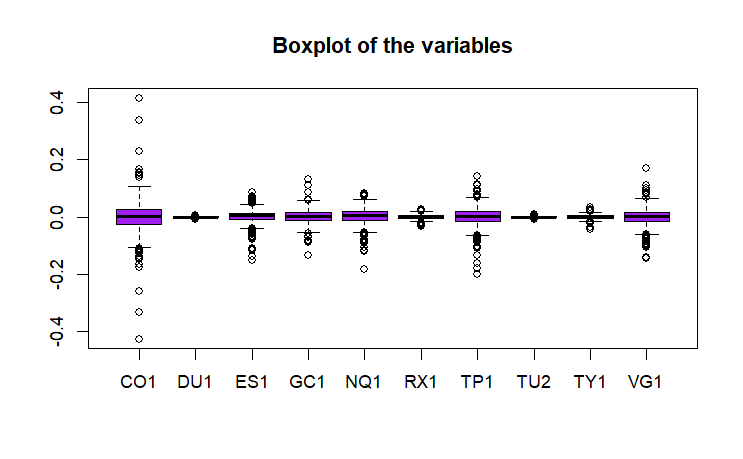

```r
boxplot(Assets, main = "Boxplot of the variables", col="purple")
```

Then we compute the PCA:

```r
PC <- princomp(Assets, scores=T)
summary(PC)
```

```
Importance of components:
                           Comp.1     Comp.2     Comp.3     Comp.4     Comp.5      Comp.6      Comp.7      Comp.8      Comp.9      Comp.10
Standard deviation     0.06416476 0.03863507 0.02389696 0.02194129 0.01672894 0.009234529 0.006714773 0.004854524 0.001327653 0.0009937038
Proportion of Variance 0.57997284 0.21027031 0.08044516 0.06781706 0.03942315 0.012012796 0.006351513 0.003319769 0.000248304 0.0001391004
Cumulative Proportion  0.57997284 0.79024315 0.87068830 0.93850537 0.97792852 0.989941314 0.996292827 0.999612596 0.999860900 1.0000000000
```

Here we can look at the proportion of variability explained by the PC

```r
layout(matrix(c(2, 3, 1, 3), 2, byrow = TRUE))

# Variance explained by the principal components
plot(PC, las = 2, main = 'Principal components', ylim = c(0, 0.008))

  # Variances of original variables
barplot(sapply(Assets, sd)^2, las = 2, main = 'Original Variables', ylim = c(0, 0.005),
          ylab = 'Variances')
```

```r
  # Plot contribution to the total variance by number of components
plot(cumsum(PC$sd^2) / sum(PC$sd^2), type = 'b', axes = FALSE,
       xlab = 'Number of components', ylab = 'Contribution to the total variance', ylim = c(0, 1))
abline(h = 1, col = 'blue')
```

[output not shown]

```r
abline(h = 0.90, lty = 2, col = 'blue')
box()
```

```r
axis(2, at = 0:10/10, labels = 0:10/10)
axis(1, at = 1:ncol(Assets), labels = 1:ncol(Assets), las = 2)
```

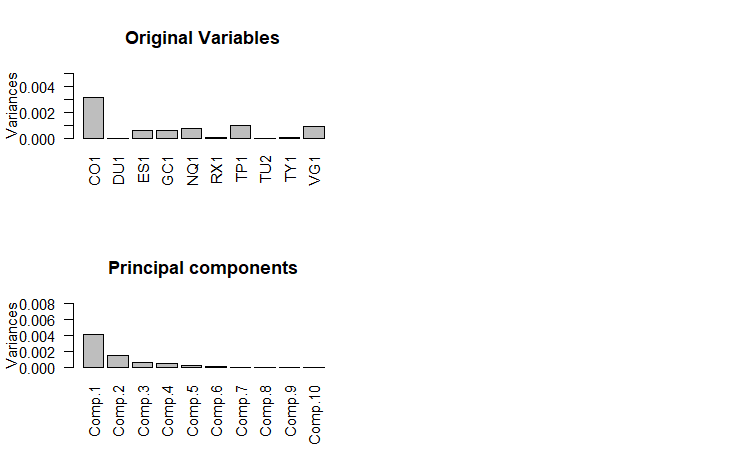

```r
par(mfrow = c(1, 1))
```

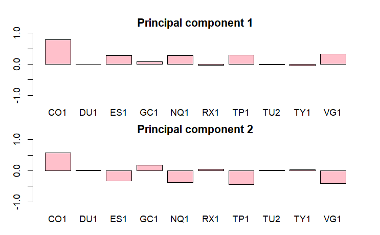

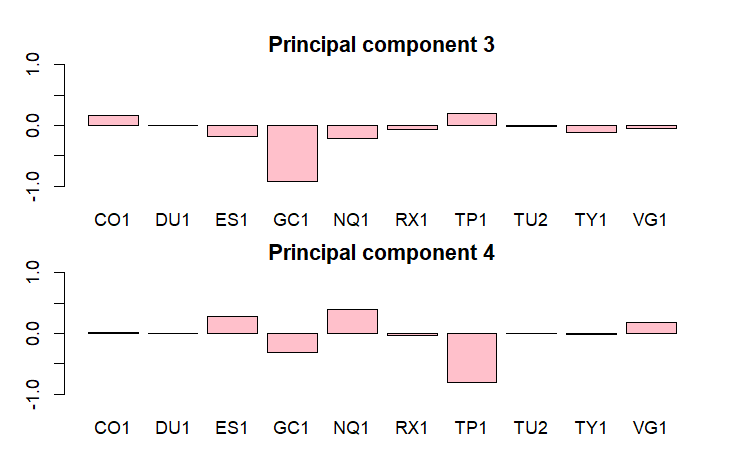

```r
#Plot of the loading among the first four PC
loadPC<-PC$loadings
par(mfrow = c(2, 1), oma = c(1, 1, 1, 1), mar = c(2, 2, 2, 1))
for(i in 1:4) barplot(loadPC[,i], ylim = c(-1, 1), col="pink",  main = paste("Principal component", i))
```

```r
print(loadPC)
```

```
Loadings:
    Comp.1 Comp.2 Comp.3 Comp.4 Comp.5 Comp.6 Comp.7 Comp.8 Comp.9 Comp.10
CO1  0.797  0.579  0.166
DU1                                                         -0.613 -0.782
ES1  0.274 -0.331 -0.172  0.281  0.206        -0.814
GC1         0.172 -0.918 -0.312        -0.121
NQ1  0.287 -0.383 -0.209  0.387  0.513         0.560
RX1                                     0.772        -0.612
TP1  0.298 -0.449  0.195 -0.801  0.172
TU2                                                   0.114 -0.778  0.612
TY1               -0.108                0.600         0.777  0.119
VG1  0.331 -0.417         0.177 -0.805  0.113  0.145

               Comp.1 Comp.2 Comp.3 Comp.4 Comp.5 Comp.6 Comp.7 Comp.8 Comp.9 Comp.10
SS loadings       1.0    1.0    1.0    1.0    1.0    1.0    1.0    1.0    1.0     1.0
Proportion Var    0.1    0.1    0.1    0.1    0.1    0.1    0.1    0.1    0.1     0.1
Cumulative Var    0.1    0.2    0.3    0.4    0.5    0.6    0.7    0.8    0.9     1.0
```

A first primary consideration that we have done is that on this component there are some variables that clearly are not influential in our model, in terms of variability, those are for instance DU1, RX1, TU2 and TY1. This might be the case in which those futures are low volatility, as a consequence after appropriate transformation we will remove it.

Linear model with the PC:

```r
score1.PC<-PC$score[,1]
score2.PC<-PC$score[,2]
score3.PC<-PC$score[,3]
score4.PC<-PC$score[,4]

fm.pc<-lm(MonsterIndex  ~ score1.PC + score2.PC + score3.PC + score4.PC)

summary(fm.pc)
```

```
Call:
lm(formula = MonsterIndex ~ score1.PC + score2.PC + score3.PC +
    score4.PC)

Residuals:
      Min        1Q    Median        3Q       Max
-0.045276 -0.003071  0.000166  0.003130  0.031077

Coefficients:
              Estimate Std. Error t value Pr(>|t|)
(Intercept)  0.0007661  0.0002073   3.695 0.000237 ***
score1.PC    0.2435649  0.0032314  75.374  < 2e-16 ***
score2.PC   -0.2665602  0.0053667 -49.669  < 2e-16 ***
score3.PC   -0.1742040  0.0086766 -20.077  < 2e-16 ***
score4.PC    0.0830285  0.0094499   8.786  < 2e-16 ***
---
Signif. codes:  0 ‘***’ 0.001 ‘**’ 0.01 ‘*’ 0.05 ‘.’ 0.1 ‘ ’ 1

Residual standard error: 0.005501 on 699 degrees of freedom
Multiple R-squared:  0.9251,    Adjusted R-squared:  0.9246
F-statistic:  2157 on 4 and 699 DF,  p-value: < 2.2e-16
```

## CONSIDERATIONS ON PCA REGRESSION

As a result we have transform our data. Now we are projecting the covariates along the principal component, consequently we will obtain the following linear model.

Y= β_0+β_1*PC_1+β_2*PC_2+β_3*PC_3+β_4*PC_4+ε

Clearly, in this way, the model is not interpretable, therefore we retransform our data with our preexisting variables.

e_ij: represents the component of the eigenvectors that maximizes the the variability

mu_i: represents the mean for each covariates.

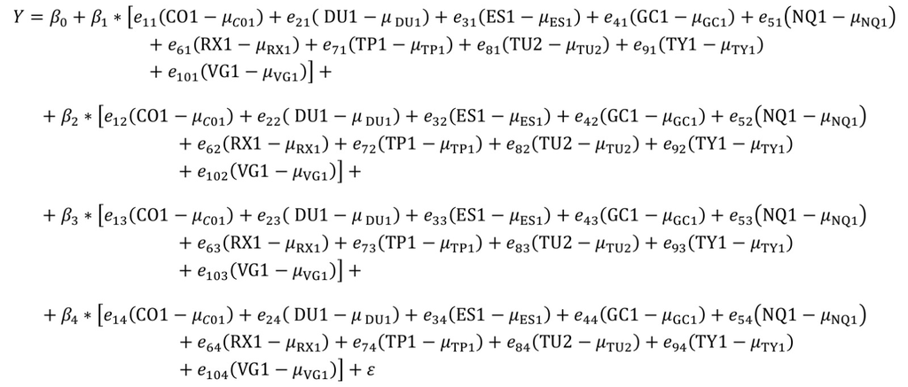

The resulting model, by grouping some coefficients, is the following:

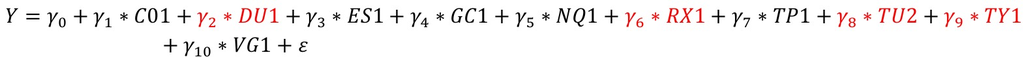

The coefficients that multiply our covariates are significantly different from the previous and are computed in such a way that the variability of our model is maximized.

Moreover, if look at the red one, we can remember that in the plot of the scores, these are the one that are not influential in terms of variability, therefore we could remove it.

Below is reported the linear model with all the previous considerations in matrix form for simplicity:

```r
m = sapply(Assets,mean)
b0 = coefficients(fm.pc)[1] - coefficients(fm.pc)[2:5]%*%t(PC$load[, 1:4])%*%m
b = PC$load[,1:4]%*%coefficients(fm.pc)[2:5]

print(b0)
```

```
              [,1]
[1,] -0.0002635005
```

```r
print(b)
```

```
            [,1]
CO1  0.012319189
DU1 -0.003515542
ES1  0.208401094
GC1  0.107780848
NQ1  0.240415800
RX1 -0.010065862
TP1  0.091786686
TU2 -0.001013485
TY1 -0.002967694
VG1  0.214642498
```

Result of our PCA-regression:

```r
AssetsMatrix<- as.matrix(Assets)
b0_vector <- rep(b0, 704)

# 2. PCA-model
Xpred =  b0_vector + AssetsMatrix %*% b

plot(Data$Date, ret2price(MonsterIndex), type = "l", col = "magenta", ylim = c(0.4, 1.8), ylab = "Price", xlab = "Year")
lines(Data$Date, ret2price(Xpred), type = "l", col = "purple")
```

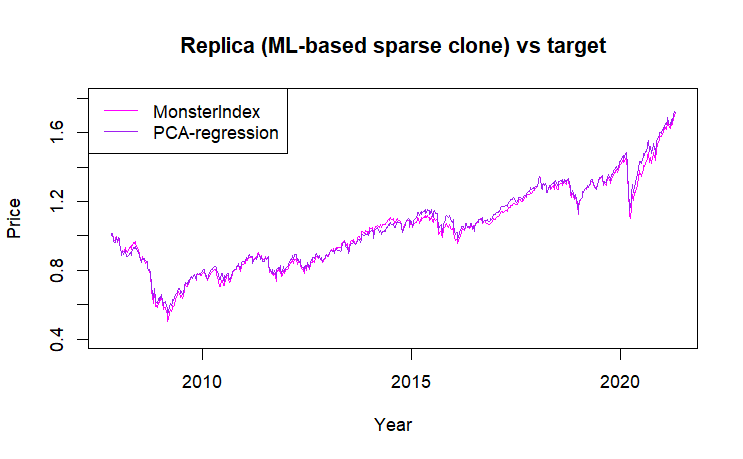

```r
legend("topleft", legend = c("MonsterIndex", "PCA-regression"), col = c("magenta", "purple"), lty = 1)
title("Replica (ML-based sparse clone) vs target")
```

```r
attach(Assets)
```

```
I seguenti oggetti sono mascherati da AssetsTrain:

    CO1, DU1, ES1, GC1, NQ1, RX1, TP1, TU2, TY1, VG1
```

```r
# Model with PCA consideration
Index.lm2 <- lm(MonsterIndex ~ GC1 + CO1 + ES1 + VG1 + NQ1 + TP1 )

detach(Assets)
summary(Index.lm2)
```

```
Call:
lm(formula = MonsterIndex ~ GC1 + CO1 + ES1 + VG1 + NQ1 + TP1)

Residuals:
       Min         1Q     Median         3Q        Max
-0.0294434 -0.0025831  0.0002778  0.0025965  0.0217274

Coefficients:
              Estimate Std. Error t value Pr(>|t|)
(Intercept) -9.229e-05  1.790e-04  -0.515   0.6064
GC1          9.830e-02  7.488e-03  13.128   <2e-16 ***
CO1          7.311e-03  3.694e-03   1.979   0.0482 *
ES1          5.446e-01  2.182e-02  24.957   <2e-16 ***
VG1          1.758e-01  9.824e-03  17.897   <2e-16 ***
NQ1         -8.676e-03  1.624e-02  -0.534   0.5933
TP1          8.346e-02  7.220e-03  11.560   <2e-16 ***
---
Signif. codes:  0 ‘***’ 0.001 ‘**’ 0.01 ‘*’ 0.05 ‘.’ 0.1 ‘ ’ 1

Residual standard error: 0.004699 on 697 degrees of freedom
Multiple R-squared:  0.9455,    Adjusted R-squared:  0.945
F-statistic:  2014 on 6 and 697 DF,  p-value: < 2.2e-16
```

#### Back testing the model

Now, as before, we perform the rolling window to capture some estimation of goodness of our model.

```r
rollingWindow = 156 # in weeks (52 = 1Y, 104 = 2Y...)
n = dim(Assets)[1]
i = 1
b <- numeric(0)
r <- 0
endSample <- 0
res <- c()
bres <- c()
AssetsMatrix<- model.matrix(MonsterIndex ~ GC1 + ES1 + VG1 + TP1, data=Assets) [,-1]

while (endSample < n-1) {
  startSample <- i
  endSample <- i + rollingWindow - 1
  X <- Assets[startSample:endSample,]
  y <- MonsterIndex[startSample:endSample]

  Index.lm4 <- lm(y ~ GC1 + ES1 + VG1 + TP1, data = X)

  b <- Index.lm4$coefficients
  bres <- rbind(bres,b)
  B0 <- b[1]

  r <- B0 + AssetsMatrix[endSample+1,] %*% b[2:5]
  res <- c(res,r)

  i = i+1;
}

sum.lm4 <- summary(Index.lm4)

start_index <- rollingWindow + 1
MonsterIndex_prices <- ret2price(MonsterIndex[start_index:n])
predicted_prices <- ret2price(res)

plot(Data$Date[1:549], MonsterIndex_prices, type = "l", col = "magenta", ylim = c(0.9, 2.2), ylab = "Price", xlab = "Year")
lines(Data$Date[1:549], predicted_prices, type = "l", col = "purple")
```

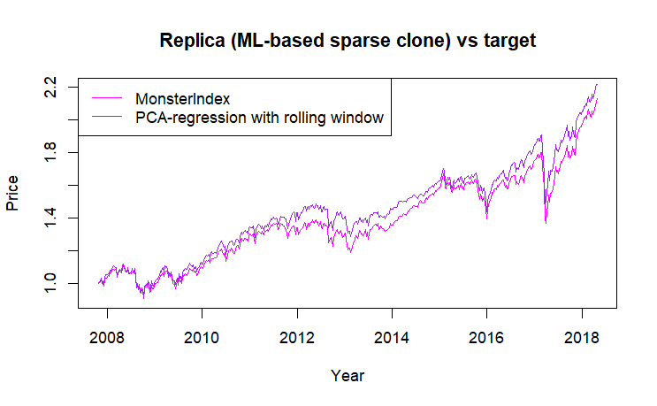

```r
legend("topleft", legend = c("MonsterIndex", "PCA-regression with rolling window"), col = c("magenta", "purple"), lty = 1)
title("Replica (ML-based sparse clone) vs target")
```

#### Computing indices

```r
# Computing MSE
MSE <- mean((MonsterIndex_prices - predicted_prices)^2)
MSE
```

```
[1] 0.004748971
```

```r
# (annualized) standard deviation of Tracking Error
TE = predicted_prices - MonsterIndex_prices
TEV <- sd(TE)*sqrt(52) # 52 means a year
TEV
```

```
[1] 0.2599066
```

```r
# annualized mean Excess Return
logRClone <- diff(log(predicted_prices))
logRTarget = diff(log(MonsterIndex_prices));
logTE =  logRClone - logRTarget;
meanTRTarget = exp(mean(logRTarget)*52) - 1
meanTRClone = exp(mean(logRClone)*52) - 1
meanER = exp(mean(logTE)*52) - 1

IR = meanER/TEV
IR
```

```
[1] 0.01443634
```

```r
# TurnOver
bres <- bres[,2:5]
Turnover = rowSums(abs(diff(bres)))/2 # weekly turnover
meanTurnover = mean(Turnover)*52 # average annual turnover
meanTurnover
```

```
[1] 0.1872783
```

```r
tradingCosts = 0.001; #transaction costs (hp: buyCosts=sellCost)
meanTradingCosts = meanTurnover*tradingCosts
meanTradingCosts
```

```
[1] 0.0001872783
```

```r
PCA.Index <- cbind(MSE,TEV,meanTRTarget,meanTRClone,meanER,IR,meanTurnover, meanTradingCosts)
PCA.Index
```

```
             MSE       TEV meanTRTarget meanTRClone      meanER         IR meanTurnover meanTradingCosts
[1,] 0.004748971 0.2599066   0.07422711  0.07825772 0.003752099 0.01443634    0.1872783     0.0001872783
```

## LASSO REGRESSION

Lasso regression is a good way to perform a variable selection and to obtain an optimal linear model.

```r
x <- model.matrix(MonsterIndexTrain ~ RX1 + TY1 + GC1 + CO1 + ES1 + VG1 +
                 NQ1 + TP1 + DU1 + TU2, data=AssetsTrain) [,-1]

lambda.grid <- 10^seq(-1, -5, length=100)
fit.lasso <- glmnet (x, MonsterIndexTrain, lambda = lambda.grid )

cv.lasso <- cv.glmnet(x,MonsterIndexTrain,lambda=lambda.grid)

bestlam.lasso <- cv.lasso$lambda.min
optlam.lasso <- cv.lasso$lambda.1se

plot(cv.lasso, col="purple")
abline(v=log(bestlam.lasso), lty=1, col="magenta" )
```

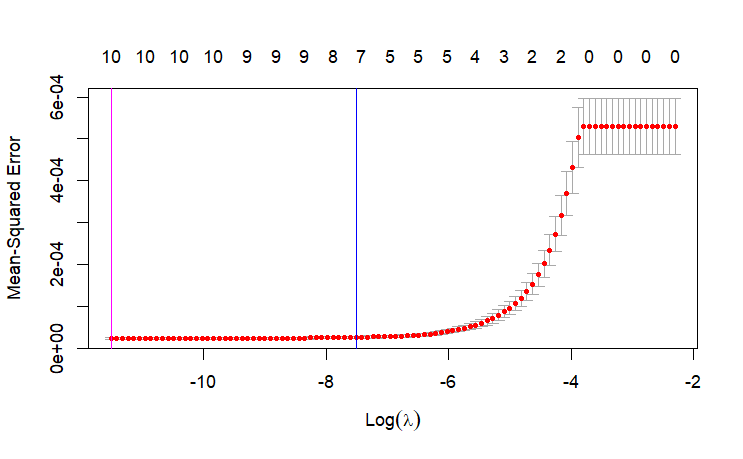

```r
abline(v=log(optlam.lasso), lty=1, col="blue")
```

In this plot we see the *best lambda* and the *optimal lambda*.

The 1<sup>st</sup> one corresponds to the value of lambda that gives minimum “mean square error”.

The `2nd` correspond to the largest value of lambda such that error is within 1 standard error of the minimum.

It is a general rule that usually we take the value of lambda for which the its value (red point) is still inside the boundary of the smallest mean-squared error.

```r
par(mfrow=c(1,1))
plot(fit.lasso, xvar='lambda',label=TRUE, col = rainbow(dim(x)[2]))
abline(v=log(bestlam.lasso), lty=1, col="magenta" )
```

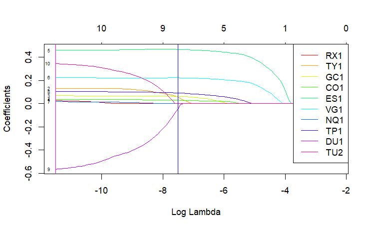

```r
abline(v=log(optlam.lasso), lty=1, col="blue")
legend('topright', dimnames(x)[[2]], col =  rainbow(dim(x)[2]), lty=1, cex=1)
```

```r
# Get the coefficients for the optimal lambda
coef.lasso <- predict(fit.lasso, s=bestlam.lasso, type = 'coefficients')[1:11,]
coef.lasso
```

```
  (Intercept)           RX1           TY1           GC1           CO1           ES1           VG1           NQ1           TP1           DU1           TU2
 3.848762e-05  2.578918e-02  1.289615e-01  6.770595e-02  3.495778e-02  4.593682e-01  2.234965e-01  1.638145e-02  1.027865e-01 -5.660533e-01  3.447881e-01
```

```r
b0.lasso = coef.lasso[1]
b.lasso <- numeric(0)
for(i in 2:11) b.lasso[i-1] = coef.lasso[i]
Xlasso = b0.lasso + x %*% b.lasso

plot(Data$Date[1:351], ret2price(MonsterIndexTrain), type = "l", col = "magenta", ylim = c(0.4, 1.2), ylab = "Price", xlab = "Year")
lines(Data$Date[1:351], ret2price(Xlasso), type = "l", col = "purple")
```

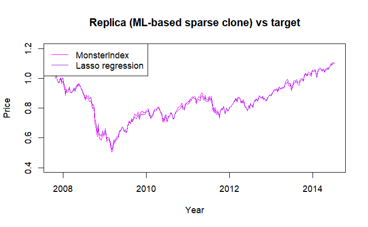

```r
legend("topleft", legend = c("MonsterIndex", "Lasso regression"), col = c("magenta", "purple"), lty = 1)
title("Replica (ML-based sparse clone) vs target")
```

#### Back testing the model

```r
rollingWindow = 156 # in weeks (52 = 1Y, 104 = 2Y...)
n = dim(Assets)[1]
i = 1
r <- 0
endSample = 0
res <- c()
bres <- c()
lambda.grid <- 10^seq(-1, -5, length=100)
x <- model.matrix(MonsterIndex ~ RX1 + TY1 + GC1 + CO1 + ES1 + VG1 +
                 NQ1 + TP1 + DU1 + TU2, data=Assets) [,-1]

options(warn = -1)
while (i + rollingWindow - 1 < n-1) {
  startSample = i
  endSample = i + rollingWindow - 1

  XX <- x[startSample:endSample,]
  y <- MonsterIndex[startSample:endSample]

  fit.lasso <- glmnet (XX, y, lambda = lambda.grid, alpha = 1 )
  cv.lasso <- cv.glmnet(XX,y,lambda=lambda.grid, alpha = 1)

  bestlam.lasso <- cv.lasso$lambda.min
  optlam.lasso <- cv.lasso$lambda.1se
  lam = (bestlam.lasso + optlam.lasso)/2

  b <- predict(fit.lasso, s=lam, type = 'coefficients')[1:11,]
  bres <- rbind(bres,b)

  if (endSample + 1 <= n) {
    r <- b[1] + x[endSample + 1, ] %*% b[2:11]
    res <- c(res, r)
  }

  i = i+1;
}
options(warn = 0)

start_index <- rollingWindow + 1
MonsterIndex_prices <- ret2price(MonsterIndex[start_index:(n-1)])
predicted_prices <- ret2price(res)

plot(Data$Date[1:548], MonsterIndex_prices, type = "l", col = "magenta", ylim = c(0.9, 2.2), ylab = "Price", xlab = "Year")
lines(Data$Date[1:548], predicted_prices, type = "l", col = "purple")
```

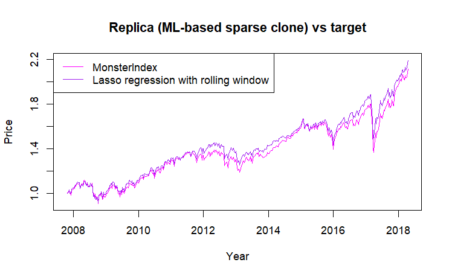

```r
legend("topleft", legend = c("MonsterIndex", "Lasso regression with rolling window"), col = c("magenta", "purple"), lty = 1)
title("Replica (ML-based sparse clone) vs target")
```

```r
# Computing MSE
MSE <- mean((MonsterIndex_prices - predicted_prices)^2)
MSE
```

```
[1] 0.002520247
```

```r
# (annualized) standard deviation of Tracking Error
TE = predicted_prices - MonsterIndex_prices
TEV <- sd(TE)*sqrt(52) # 52 means a year
TEV
```

```
[1] 0.2216868
```

```r
# annualized mean Excess Return
logRClone <- diff(log(predicted_prices))
logRTarget = diff(log(MonsterIndex_prices));
logTE =  logRClone - logRTarget;
meanTRTarget = exp(mean(logRTarget)*52) - 1
meanTRClone = exp(mean(logRClone)*52) - 1
meanER = exp(mean(logTE)*52) - 1

IR = meanER/TEV
IR
```

```
[1] 0.01542335
```

```r
#TurnOver
bres <- bres[,2:11]
Turnover = rowSums(abs(diff(bres)))/2 # weekly turnover
meanTurnover = mean(Turnover)*52 # average annual turnover
meanTurnover
```

```
[1] 4.467569
```

```r
tradingCosts = 0.001; #transaction costs (hp: buyCosts=sellCost)
meanTradingCosts = meanTurnover*tradingCosts
```

```r
LASSO.Index <- cbind(MSE,TEV,meanTRTarget,meanTRClone,meanER,IR,meanTurnover, meanTradingCosts)
LASSO.Index
```

```
             MSE       TEV meanTRTarget meanTRClone      meanER         IR meanTurnover meanTradingCosts
[1,] 0.002520247 0.2216868   0.07354749  0.07721812 0.003419154 0.01542335     4.467569      0.004467569
```

## ELASTIC NET

Elastic net is another good choice to make variable selection and to perform the linear model. In fact this is the combination of the Lasso model and the RIdge one. Both of them forced the coefficients of our linear model to be zero and as a consequence reducing the dimension to get a more flexible model.

```r
x <- model.matrix(MonsterIndexTrain ~ RX1 + TY1 + GC1 + CO1 + ES1 + VG1 +
                 NQ1 + TP1 + DU1 + TU2, data=AssetsTrain) [,-1]

lambda.grid <- 10^seq(-1, -5, length=100)
fit.EN <- glmnet (x, MonsterIndexTrain, lambda = lambda.grid, alpha=0.5 )

cv.EN <- cv.glmnet(x,MonsterIndexTrain,lambda=lambda.grid, alpha=0.5)

bestlam.EN <- cv.EN$lambda.min
optlam.EN <- cv.EN$lambda.1se

plot(cv.EN, col="purple")
abline(v=log(bestlam.EN), lty=1, col="magenta" )
```

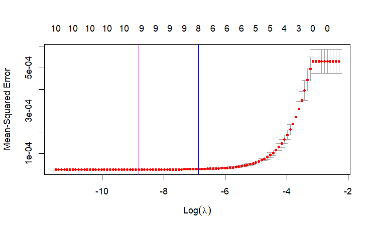

```r
abline(v=log(optlam.EN), lty=1, col="blue")
```

For the choice of the lambda there is an analogus procedure followed in the Lasso Regression.

```r
par(mfrow=c(1,1))
plot(fit.EN, xvar='lambda',label=TRUE, col = rainbow(dim(x)[2]))
abline(v=log(bestlam.EN), lty=1, col="magenta" )
```

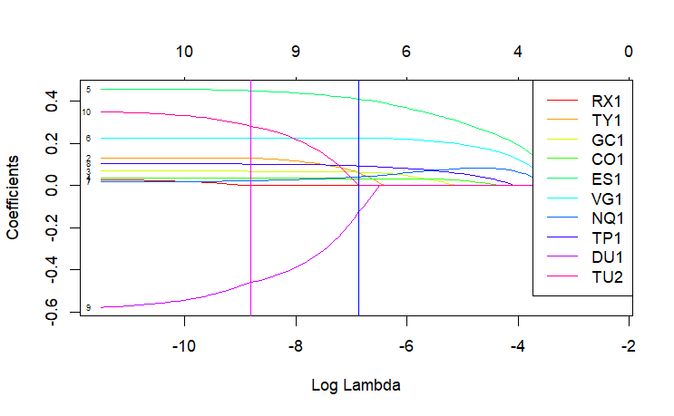

```r
abline(v=log(optlam.EN), lty=1, col="blue")
legend('topright', dimnames(x)[[2]], col =  rainbow(dim(x)[2]), lty=1, cex=1)
```

```r
coef.EN <- predict(fit.EN, s=bestlam.EN, type = 'coefficients')[1:11,]
coef.EN
```

```
  (Intercept)           RX1           TY1           GC1           CO1           ES1           VG1           NQ1           TP1           DU1           TU2
 4.181244e-05  0.000000e+00  1.308842e-01  6.761403e-02  3.462316e-02  4.492250e-01  2.226727e-01  2.277799e-02  1.017960e-01 -4.597627e-01  2.822575e-01
```

Our model with the Elastic Net:

```r
b0.EN = coef.EN[1]
b.EN <- numeric(0)
for(i in 2:11) b.EN[i-1] = coef.EN[i]
XEN = b0.EN + x %*% b.EN

plot(Data$Date[1:351], ret2price(MonsterIndexTrain), type = "l", col = "magenta", ylim = c(0.4, 1.3), ylab = "Price", xlab = "Year")
lines(Data$Date[1:351], ret2price(XEN), type = "l", col = "purple")
```

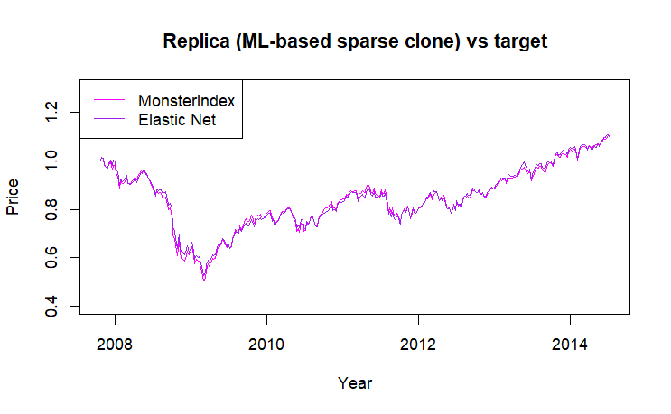

```r
legend("topleft", legend = c("MonsterIndex", "Elastic Net"), col = c("magenta", "purple"), lty = 1)
title("Replica (ML-based sparse clone) vs target")
```